# Práctica Final

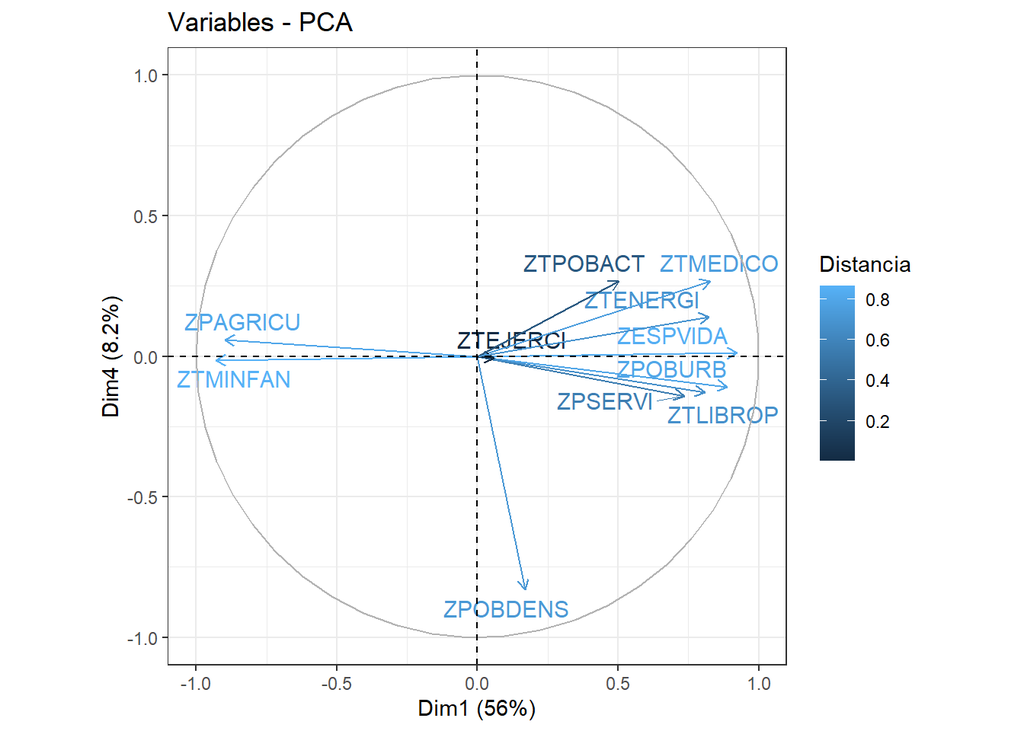

```r
fviz_pca_var(PCA,axes=c(1,4),
             repel=TRUE,col.var="cos2",
             legend.title="Distancia")+theme_bw()
```

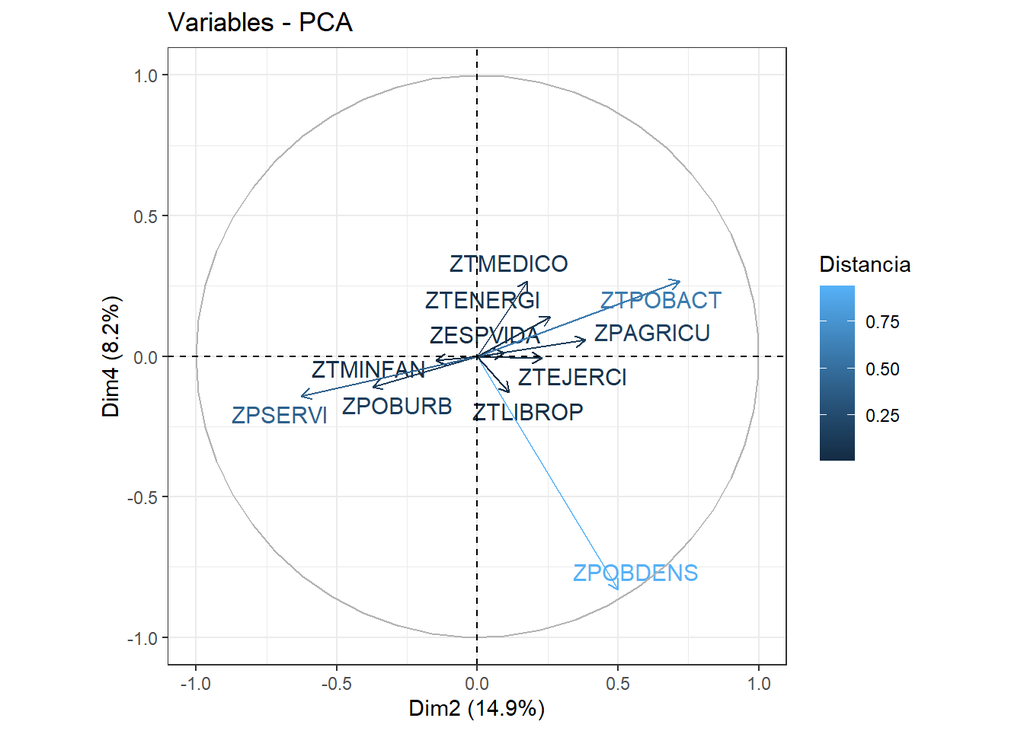

```r
fviz_pca_var(PCA,axes=c(2,4),
             repel=TRUE,col.var="cos2",
             legend.title="Distancia")+theme_bw()
```

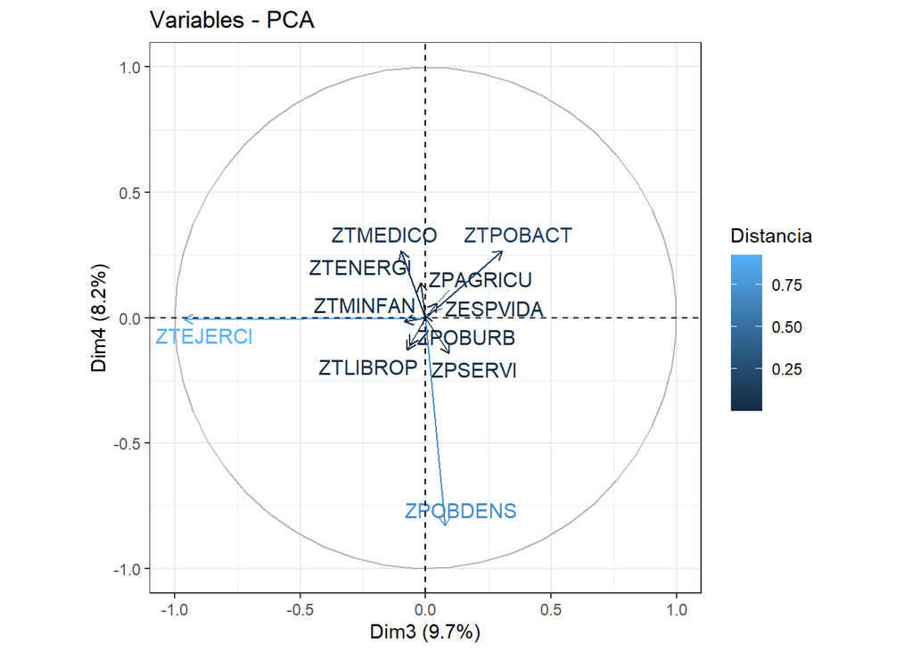

```r
fviz_pca_var(PCA,axes=c(3,4),
             repel=TRUE,col.var="cos2",
             legend.title="Distancia")+theme_bw()
```

Es posible también representar las observaciones de los objetivos junto con las componentes principales mediante la orden `contrib` de la función `fviz_pca_ind`, así como identificar con colores aquellas observaciones que mayor varianza explican de las componentes principales.

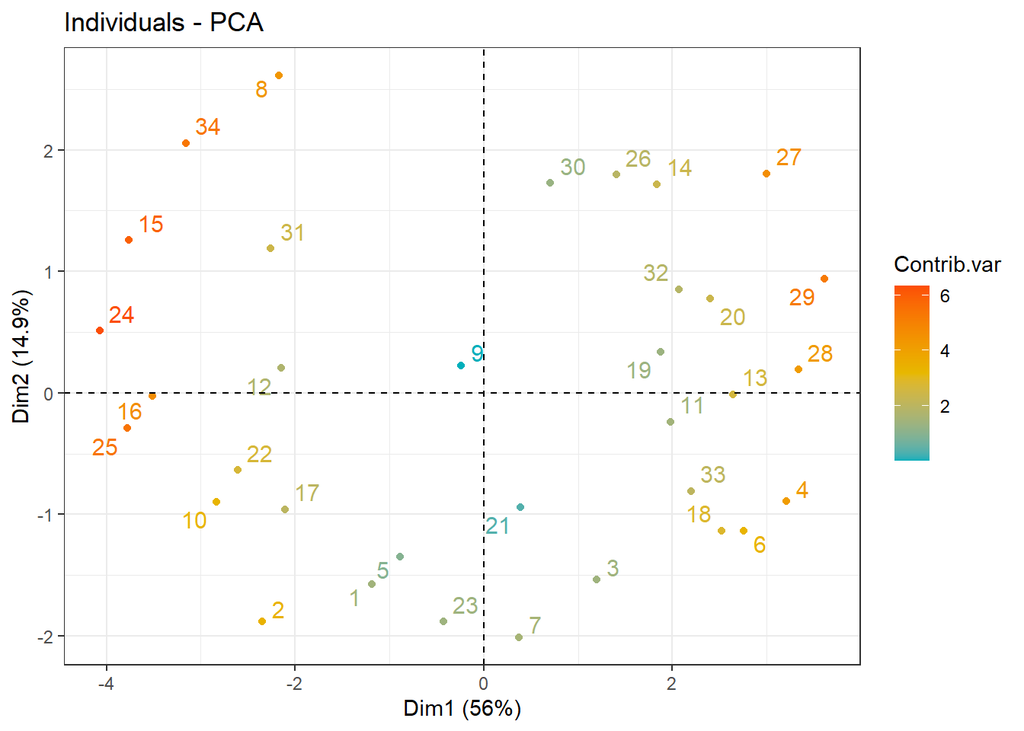

```r
fviz_pca_ind(PCA,col.ind = "contrib",
             gradient.cols = c("#00AFBB", "#E7B800", "#FC4E07"),
             repel=TRUE,legend.title="Contrib.var")+theme_bw()
```

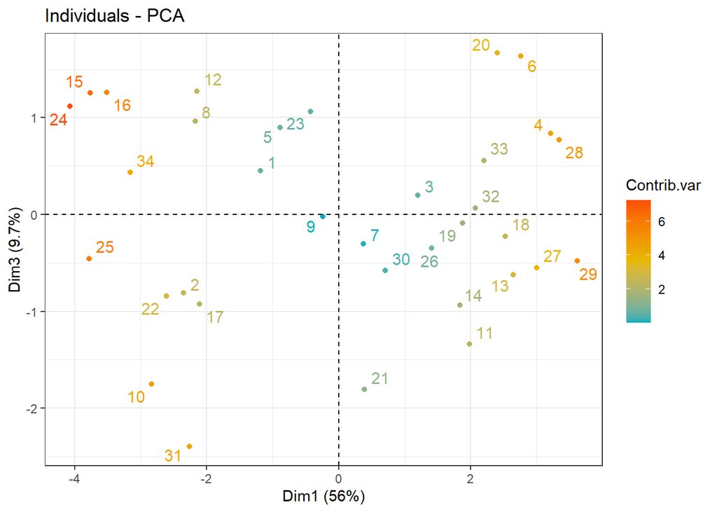

```r
fviz_pca_ind(PCA,axes=c(1,3),col.ind = "contrib",
             gradient.cols = c("#00AFBB", "#E7B800", "#FC4E07"),
             repel=TRUE,legend.title="Contrib.var")+theme_bw()
```

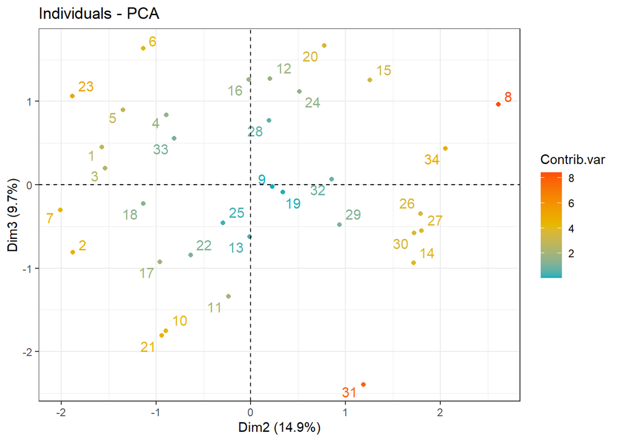

```r
fviz_pca_ind(PCA,axes=c(2,3),col.ind = "contrib",
             gradient.cols = c("#00AFBB", "#E7B800", "#FC4E07"),
             repel=TRUE,legend.title="Contrib.var")+theme_bw()
```

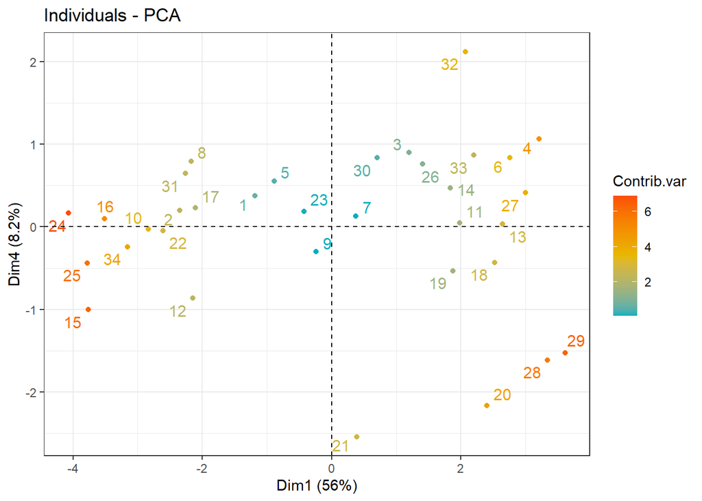

```r
fviz_pca_ind(PCA,axes=c(1,4),col.ind = "contrib",
             gradient.cols = c("#00AFBB", "#E7B800", "#FC4E07"),
             repel=TRUE,legend.title="Contrib.var")+theme_bw()
```

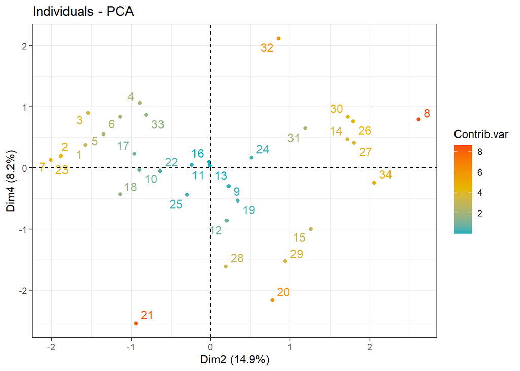

```r
fviz_pca_ind(PCA,axes=c(2,4),col.ind = "contrib",
             gradient.cols = c("#00AFBB", "#E7B800", "#FC4E07"),
             repel=TRUE,legend.title="Contrib.var")+theme_bw()
```

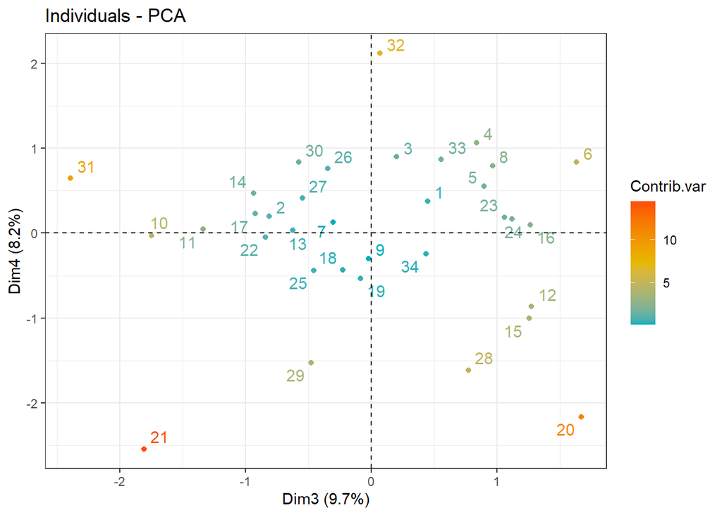

```r
fviz_pca_ind(PCA,axes=c(3,4),col.ind = "contrib",
             gradient.cols = c("#00AFBB", "#E7B800", "#FC4E07"),
             repel=TRUE,legend.title="Contrib.var")+theme_bw()
```

También mostraremos la representación conjunta de variables y observaciones que relaciona visualmente las posibles relaciones entre las observaciones, las contribuciones de los individuos a las varianzas de las componentes y el peso de las variables en cada componente principal.

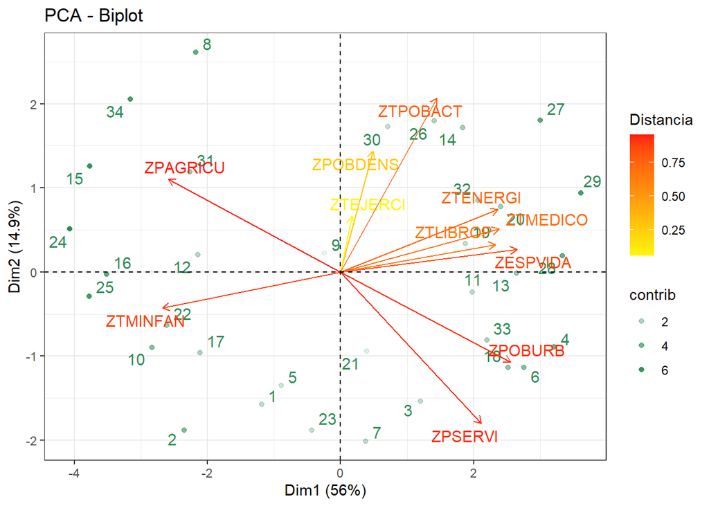

```r
fviz_pca(PCA,
         alpha.ind ="contrib", col.var = "cos2",col.ind="seagreen",
         gradient.cols = c("#FDF50E", "#FD960E", "#FD1E0E"),
         repel=TRUE,
         legend.title="Distancia")+theme_bw()
```

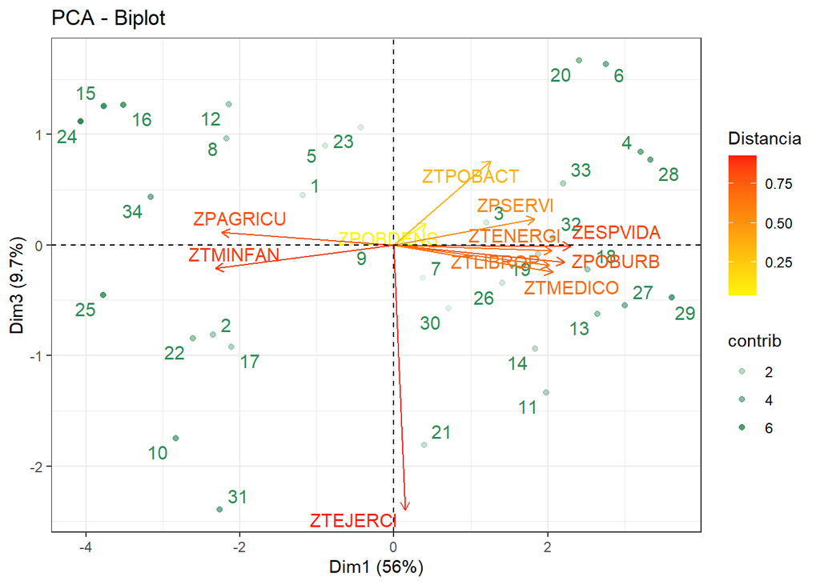

```r
fviz_pca(PCA,axes=c(1,3),
         alpha.ind ="contrib", col.var = "cos2",col.ind="seagreen",
         gradient.cols = c("#FDF50E", "#FD960E", "#FD1E0E"),
         repel=TRUE,
         legend.title="Distancia")+theme_bw()
```

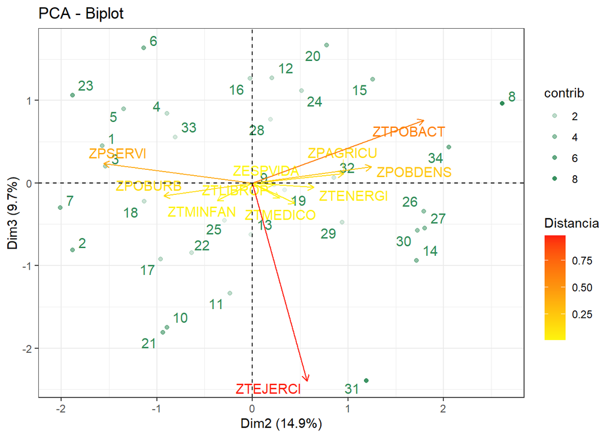

```r
fviz_pca(PCA,axes=c(2,3),
         alpha.ind ="contrib", col.var = "cos2",col.ind="seagreen",
         gradient.cols = c("#FDF50E", "#FD960E", "#FD1E0E"),
         repel=TRUE,
         legend.title="Distancia")+theme_bw()
```

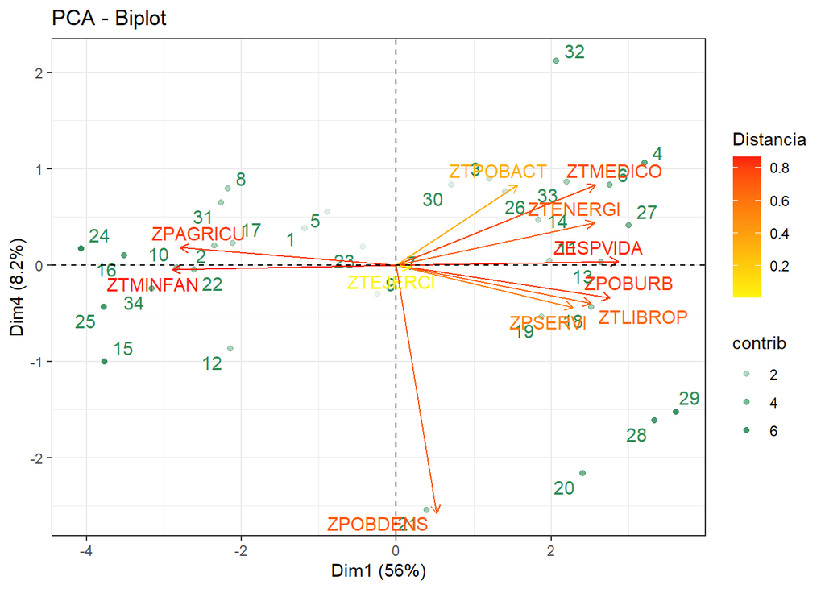

```r
fviz_pca(PCA,axes=c(1,4),
         alpha.ind ="contrib", col.var = "cos2",col.ind="seagreen",
         gradient.cols = c("#FDF50E", "#FD960E", "#FD1E0E"),
         repel=TRUE,
         legend.title="Distancia")+theme_bw()
```

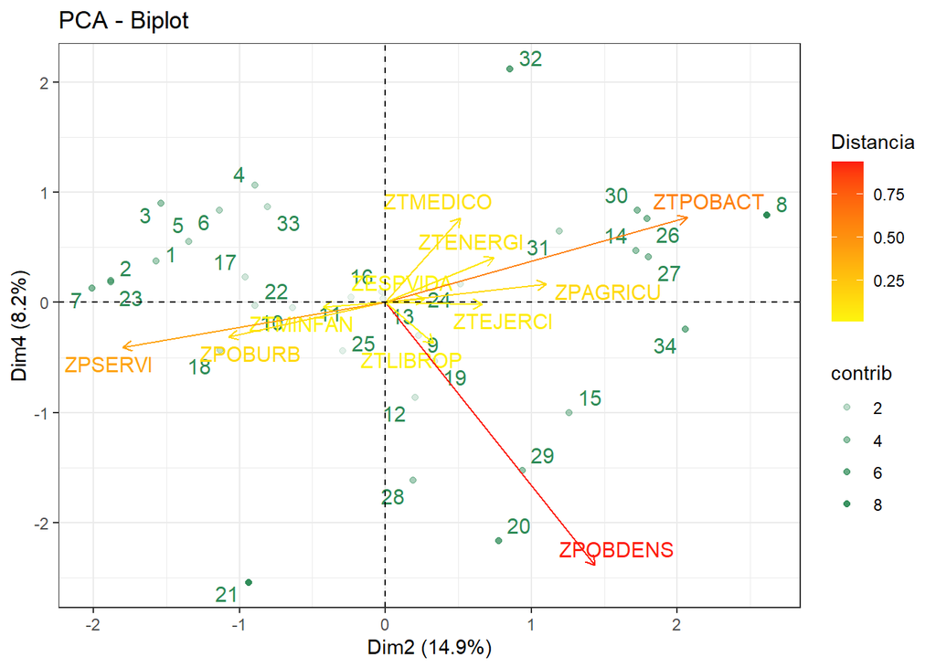

```r
fviz_pca(PCA,axes=c(2,4),
         alpha.ind ="contrib", col.var = "cos2",col.ind="seagreen",
         gradient.cols = c("#FDF50E", "#FD960E", "#FD1E0E"),
         repel=TRUE,
         legend.title="Distancia")+theme_bw()
```

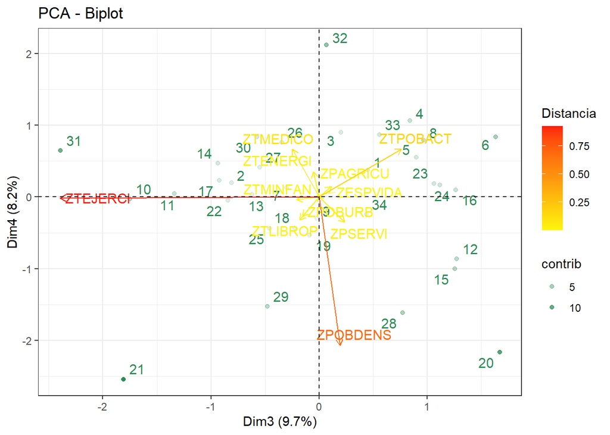

```r
fviz_pca(PCA,axes=c(3,4),
         alpha.ind ="contrib", col.var = "cos2",col.ind="seagreen",
         gradient.cols = c("#FDF50E", "#FD960E", "#FD1E0E"),
         repel=TRUE,
         legend.title="Distancia")+theme_bw()
```

Por último, ya que el objeto de este estudio era reducir la dimensión de las variables utilizadas, es posible obtener las coordenadas de los datos originales tipificados en el nuevo sistema de referencia. De hecho, lo tenemos almacenados desde que utilizamos la función `prcomp` para crear la variable PCA:

```r
head(PCA$x,n=4)
```

```
##            PC1        PC2        PC3       PC4        PC5        PC6        PC7
## [1,] -1.187951 -1.5717487  0.4504449 0.3781493  1.4228328 -0.2719916 -0.6235956
## [2,] -2.346246 -1.8810662 -0.8108192 0.2014503  0.4528028 -0.2176741 -0.1130183
## [3,]  1.197924 -1.5383367  0.2007784 0.8972738 -0.3885080 -0.7714447  0.8072288
## [4,]  3.206851 -0.8941585  0.8394015 1.0652724  0.5502835  0.3851821 -0.8118040
##              PC8        PC9       PC10          PC11
## [1,] -0.09144981  0.3475349  0.3629623  0.0009993838
## [2,]  0.67613362  0.3189091 -0.2221354 -0.1452388044
## [3,] -0.15129705 -0.4099810  0.1343895 -0.0562911808
## [4,]  0.25022260 -0.1619369 -0.3806793  0.2406669888
```

### *Mediante variables latentes*

```r
poly_cor<-hetcor(datos)$correlations
```

```r
### prueba de dos modelos con 4 factores
modelo1<-fa(poly_cor,
            nfactors = 4,
            rotate = "none",
            fm="mle") # modelo m?xima verosimilitud
modelo2<-fa(poly_cor,
            nfactors = 4,
            rotate = "none",
            fm="minres") # modelo m?nimo residuo
```

Comparamos las comunalidades:

```r
sort(modelo1$communality,decreasing = T)->c1
sort(modelo2$communality,decreasing = T)->c2
head(cbind(c1,c2))
```

```
##                 c1        c2
## ZESPVIDA 0.9950372 0.9965404
## ZPSERVI  0.9950088 0.9770469
## ZPAGRICU 0.9869721 0.9623442
## ZTMINFAN 0.9570766 0.9615350
## ZTPOBACT 0.9308581 0.9268302
## ZPOBURB  0.9189274 0.8906327
```

Comparamos las unicidades, es decir, la proporción de varianza que no ha sido explicada por el factor (1-comunalidad)

```r
sort(modelo1$uniquenesses,decreasing = T)->u1
sort(modelo2$uniquenesses,decreasing = T)->u2
head(cbind(u1,u2))
```

```
##                  u1        u2
## ZPOBDENS 0.91828075 0.9114458
## ZTEJERCI 0.55545259 0.4061738
## ZTLIBROP 0.41334538 0.3065013
## ZTMEDICO 0.28516979 0.1645934
## ZTENERGI 0.11530601 0.1630354
## ZPOBURB  0.08107256 0.1093673
```

Determinemos ahora el número óptimo de factores. Hay diferentes criterios, entre los que destacan el Scree plot y el análisis paralelo:

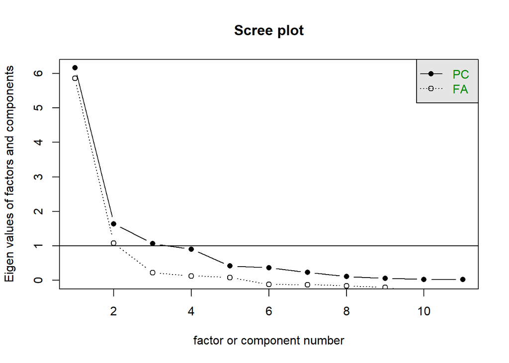

```r
scree(poly_cor)
```

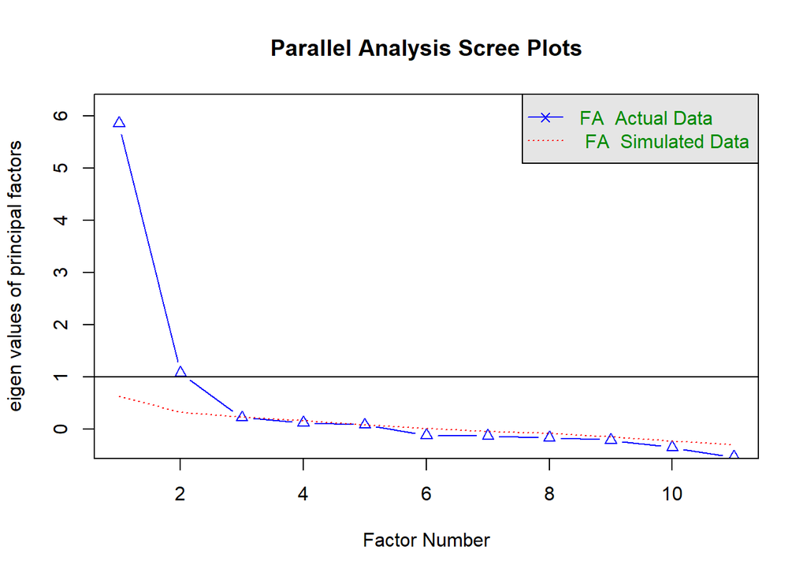

```
## Parallel analysis suggests that the number of factors =  2  and the number of components =  NA
```

```r
fa.parallel(poly_cor,n.obs=200,fa="fa",fm="minres")
```

Estimamos el modelo factorial con 2 factores implementando una rotación tipo varimax para buscar una interpretación más simple:

```r
modelo_varimax<-fa(poly_cor,nfactors = 2,rotate = "varimax",
                   fa="mle")
```

Mostramos la mariz de pesos factorial rotada:

```r
print(modelo_varimax$loadings,cut=0)
```

```
##
## Loadings:
##          MR1    MR2
## ZPOBDENS  0.023  0.285
## ZTMINFAN -0.756 -0.574
## ZESPVIDA  0.769  0.509
## ZPOBURB   0.964  0.057
## ZTMEDICO  0.631  0.524
## ZPAGRICU -0.985 -0.051
## ZPSERVI   0.941 -0.245
## ZTLIBROP  0.647  0.425
## ZTEJERCI  0.000  0.115
## ZTPOBACT  0.135  0.839
## ZTENERGI  0.603  0.575
##
##                  MR1   MR2
## SS loadings    5.143 2.239
## Proportion Var 0.468 0.204
## Cumulative Var 0.468 0.671
```

Visualmente podríamos hacer el esfuerzo de ver con qué variables correlacionan cada uno de los factores, pero es muy tedioso; de modo que utilizamos la siguiente representación:

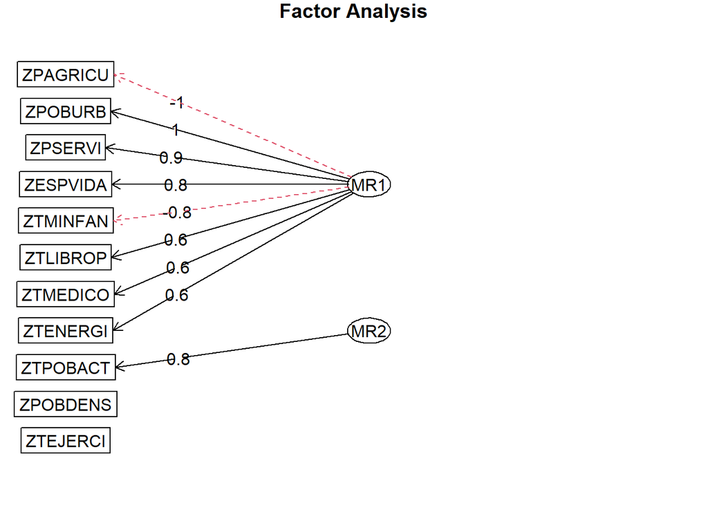

```r
fa.diagram(modelo_varimax)
```

En este diagrama, entre otras cosas, se ve que el primer factor está asociado con los items `ZPAGRICU`, `ZPOBURB`, `ZPSERVI`, `ZESPVIDA`, `ZTMINFAN`, `ZTLIBROP`, `ZTMEDICO`, `ZTENERGI`; mientras que el segundo factor está asociado solo al item `ZTPOPBACT`.

Otra forma de hacerlo es con un test de hipótesis al final que contrasta si el número de factores es suficiente:

```r
factanal(datos,factors=2, rotation="none")
```

```
##
## Call:
## factanal(x = datos, factors = 2, rotation = "none")
##
## Uniquenesses:
## ZPOBDENS ZTMINFAN ZESPVIDA  ZPOBURB ZTMEDICO ZPAGRICU  ZPSERVI ZTLIBROP
##    0.908    0.020    0.053    0.071    0.402    0.051    0.085    0.446
## ZTEJERCI ZTPOBACT ZTENERGI
##    0.987    0.341    0.453
##
## Loadings:
##          Factor1 Factor2
## ZPOBDENS  0.147   0.266
## ZTMINFAN -0.960  -0.244
## ZESPVIDA  0.953   0.195
## ZPOBURB   0.889  -0.373
## ZTMEDICO  0.763   0.128
## ZPAGRICU -0.887   0.403
## ZPSERVI   0.758  -0.584
## ZTLIBROP  0.743
## ZTEJERCI          0.111
## ZTPOBACT  0.460   0.669
## ZTENERGI  0.732   0.104
##
##                Factor1 Factor2
## SS loadings      5.884   1.298
## Proportion Var   0.535   0.118
## Cumulative Var   0.535   0.653
##
## Test of the hypothesis that 2 factors are sufficient.
## The chi square statistic is 63.09 on 34 degrees of freedom.
## The p-value is 0.00176
```

## *Análisis de normalidad*

Utilizaremos el **test de normalidad multivariante (Mardia, Henze-Zikler y Royston)**. El paquete `MVN` contiene funciones que permiten realizar los tres test que se utilizan habitualmente para contrastar la normalidad multivariante. Esta normalidad multivariante puede verse afectada por la presencia de outliers. En este paquete también encontraremos funciones para el análisis de outliers.

```r
outliers <- mvn(data = datos, mvnTest = "hz", multivariateOutlierMethod = "quan")
```

[figure not shown]

Se detectan 11 outliers en las observaciones 1, 4, 6, 7, 15, 19, 20, 21, 28, 29 y 33. Por otra parte, al realizar los dos test siguientes obtenemos que:

- El test de Royston: Encuentra evidencias al 5% de significación de falta de normalidad multivariante.
- El test de Henze-Zierkler: No encuentra evidencias al 5% de significación de falta de normalidad multivariante.

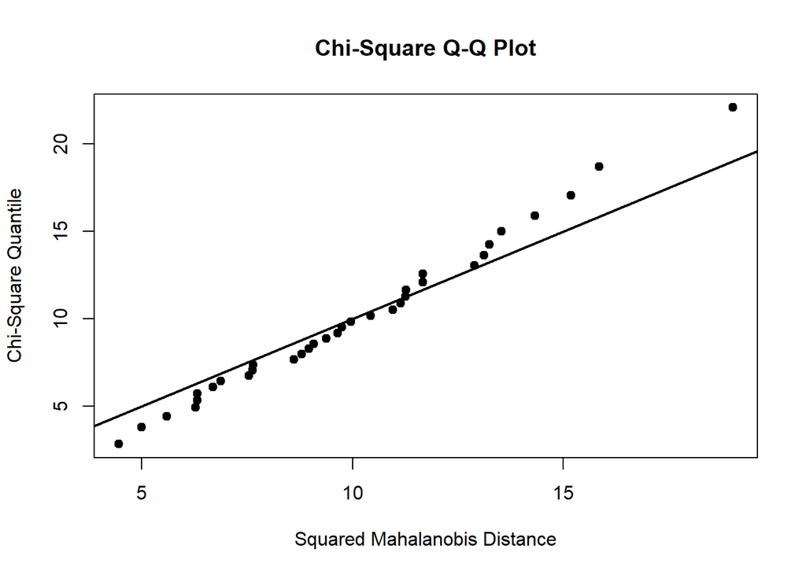

```r
royston_test <- mvn(data = datos[,-1], mvnTest = "royston", multivariatePlot = "qq")
```

```r
royston_test$multivariateNormality
```

```
##      Test        H      p value MVN
## 1 Royston 20.14884 0.0002442053  NO
```

```r
hz_test <- mvn(data = datos, mvnTest = "hz")
hz_test$multivariateNormality
```

```
##            Test        HZ   p value MVN
## 1 Henze-Zirkler 0.9888665 0.0761232 YES
```

## *Construcción de un clasificador*

```r
datos_i<-read.csv("DatosBD3Listos.csv")
```

### Caso lineal

Cuando se emplean **múltiples predictores**, se tiene que contrastar que la matriz de covarianzas es constante en todos los grupos. en este caso es también recomendable comprobar la homogeneidad de la varianza para cada predictor a nivel individual. El test más recomendable es el **test de Box M**, que es una extensión del de Barttlet para escenarios multivariantes. Hay que tener en cuenta que es muy sensible a que lso datos efectivamente se distribuyan según una normal multivariante. Por este motivo se recomienda utilizar una significación (p-value)<0.001.

Mientras tanto, cuando hay un **solo predictor**, el test más recomendable es el **test de Barttlet**, ya utilizado anteriormente.

```r
cortest.bartlett(datos_i[,2:12])
```

```
## R was not square, finding R from data
```

```
## $chisq
## [1] 1128.433
##
## $p.value
## [1] 3.790271e-200
##
## $df
## [1] 55
```

Debido a que solo hay 34 filas y cada fila hace referencia a un país distinto no se pudo realizar el análisis discriminante lineal. La función `lda` daba el error de que las variables eran constantes. Para realizar el análisis discriminante lineal, se volvió a copiar y pegar dos veces las 34 filas haciendo algunos cambios para que las variables no fuesen colineales. En la primera tanda, se sumó a todos los valores numéricos 0’5 y a los valores más grande se les volvió a sumar un valor entre [0,0’5] para reflejar el mayor peso que tendrían en el análisis. En la segunda tanda, por su parte, se restó 0’5 y a los valores más pequeños se volvió a restar un valor entre [0,0’5]. Tras esto, tendríamos un archivo con los datos originales, junto con los datos sumados y restados. Ahora ya podemos hacer `lda`.

Una vez hecho esto, calculamos la función discrimintante. La función `lda` del paquete `MASS` realiza la clasificación:

```r
modelo_lda <- lda(formula = PAIS ~ ZESPVIDA + ZPOBDENS + ZPOBURB + ZTMEDICO + ZTMINFAN + ZPAGRICU + ZPSERVI + ZTLIBROP + ZTEJERCI + ZTPOBACT + ZTENERGI, data = datos_i)
modelo_lda
```

```
## Call:
## lda(PAIS ~ ZESPVIDA + ZPOBDENS + ZPOBURB + ZTMEDICO + ZTMINFAN +
##     ZPAGRICU + ZPSERVI + ZTLIBROP + ZTEJERCI + ZTPOBACT + ZTENERGI,
##     data = datos_i)
##
## Prior probabilities of groups:
##   africasu   argelia    argentin   australi   brasil     canada     chile
## 0.02941176 0.02941176 0.02941176 0.02941176 0.02941176 0.02941176 0.02941176
##   china      coreasur   egipto     espana     filipina   francia    humgria
## 0.02941176 0.02941176 0.02941176 0.02941176 0.02941176 0.02941176 0.02941176
##   india      indonesi   iran       israel     italia     japon      libano
## 0.02941176 0.02941176 0.02941176 0.02941176 0.02941176 0.02941176 0.02941176
##   marrueco   mejico     nigeria    pakistan   polonia    rdaleman   reinouni
## 0.02941176 0.02941176 0.02941176 0.02941176 0.02941176 0.02941176 0.02941176
##   rfaleman   rumania    turquia    urss       usa        vietnam
## 0.02941176 0.02941176 0.02941176 0.02941176 0.02941176 0.02941176
##
## Group means:
##             ZESPVIDA     ZPOBDENS     ZPOBURB    ZTMEDICO    ZTMINFAN
## africasu -1.66652150 -0.907191432 -0.21488857 -0.73382516  0.96148387
## argelia  -0.89488793 -1.133383755 -0.81526232 -0.88765979  1.21338387
## argentin  0.43886285 -0.991855947  1.13811356  1.26602514 -0.31857942
## australi  1.08192126 -1.161167394  1.28029344  0.49685195 -1.02030085
## brasil   -0.32328046 -0.949384831  0.44097348 -0.31077990  0.61190835
## canada    1.24622189 -1.072654656  0.81706220  0.51608128 -1.02801208
## chile     0.47458832 -0.945241307  1.06473039 -0.87484648 -0.46766309
## china     0.27214400 -0.022271439 -1.83591015 -0.88446114 -0.29287533
## coreasur  0.12924213  3.028287610 -0.04519000 -0.66652250 -0.47280391
## egipto   -1.02588131 -0.667625230 -0.60473665 -1.13764108  1.48070632
## espana    1.07001277 -0.326820419  0.68405522  0.97758519 -1.01001922
## filipina -0.54954175  0.571288308 -0.93954734 -1.10879709  0.04641855
## francia   1.10573824 -0.052311985  0.70240101  0.68914524 -1.03829371
## humgria   0.47458832  0.094783101 -0.20112923  1.46793310 -0.69899983
## india    -1.45458692  1.155987989 -1.69831672 -0.86843046  1.71826415
## indonesi -1.66652150 -0.280205779 -1.75335409 -1.14725575  1.40359407
## iran     -0.58526722 -0.850976147 -0.40293294 -1.07033843  0.70958386
## israel    0.86756846  0.035737891  1.49204732  1.16987849 -0.67072534
## italia    1.07001277  0.842689099  0.39510900  1.55446508 -0.92776616
## japon     1.24864011  2.318709204  0.83999444  0.02573337 -1.10255392
## libano   -0.06129369  1.728257100  0.80788931 -0.27232124 -0.06153860
```

[output cut: 98 more lines]

```
## ZESPVIDA -0.5869901 -5.5320526 -3.2220144  5.83339828  0.310755585
## ZPOBDENS -4.0045112  0.3984845  0.5178981  0.27648877  0.068893975
## ZPOBURB   1.4696059  9.8891405 -8.0743674 -4.34226936  0.132840342
## ZTMEDICO -3.1914907 -2.2968708  3.1776791 -0.80097594  0.129297964
## ZTMINFAN  1.7061147  2.2197296 -0.4693296  7.01493698  0.432398405
## ZPAGRICU -0.6156956 -3.6616292 -1.0731522 -7.16456258  0.436682793
## ZPSERVI  -0.3086941 -3.8453929 10.0506396 -0.44251690  0.242999873
## ZTLIBROP  8.6310146 -3.0438981  1.4116230 -0.14160253  0.020397239
## ZTEJERCI -0.2615594  0.8397101 -0.5964485  0.06520368 -0.001463341
## ZTPOBACT  3.6385479  6.3631895  4.6566112  2.43141725  0.010644980
## ZTENERGI -5.9780645 -1.2066770 -5.8838591 -2.20557348  0.096737099
##
## Proportion of trace:
##    LD1    LD2    LD3    LD4    LD5    LD6    LD7    LD8    LD9   LD10   LD11
## 0.5716 0.1502 0.1139 0.0625 0.0359 0.0303 0.0159 0.0113 0.0071 0.0013 0.0000
```

La salida de este objeto, nos muestra las **probabilidades a priori** de cada grupo, en este caso 0.02941176 para cada país (1/34), las **medias de cada regresor por grupo** y los **coeficientes del modelo de clasificación discriminante lineal**, que en este caso tendría la forma:

$$\begin{align}
LD1 & = -3.1612867\times ZESPVIDA - 0.8617174 \times ZPOBDENS +
0.2152631\times ZPOBURB - 4.1192290 \times ZTMEDICO \\
&+ 18.9828752 \times ZTMINFAN + 1.6527333 \times ZPAGRICU -
1.2191577 \times ZPSERVI - 1.9482100 \times ZTLIBROP \\
&+ 0.2774037 \times ZTEJERCI - 4.8002149 \times ZTPOBACT - 4.5633318
\times ZTENERGI
\end{align}$$

Y lo mismo con el resto de discriminantes lineales.

La `proportion of trace` que imprime también es el porcentaje de separación conseguido por cada función discriminante.

### Caso cuadrático

Igual que en el caso lineal no se pudo hacer `lda`, aquí tampoco se pudo hacer `qda`. En este caso, el error era que algún grupo era demasiado pequeño. Además en este caso, no encontramos ninguna manera de intentar añadir datos para intentar hacer `qda`. Mirando el código de la función `qda`, se exigía que cada clase de la variable PAIS tuviera como mínimo p+1 observaciones donde p es el número de variables. Creamos de nuevo un archivo que contuviera estas p+1 observaciones por cada país pero la instrucción `qda` volvía a dar error. Ahora el error era que el rango era deficiente para un país en concreto. Buscamos el error en internet y pudimos encontrar que o se debía a algún error en el conjunto de datos o la información de los datos era insuficiente (algo que consideramos totalmente lógico debido a la modificación arbitraria de los datos por nuestra parte). Sin embargo, lo más peculiar era que la instrucció `qda` sí se ejecutaba correctamente si la fórmula que introducíamos era de una sola variable mientras que si la fórmula era la misma que la usada en `lda` provocaba un error. Por este motivo, no hemos podido realizar un análisis discriminante cuadrático ni su correspondiente validación.

## *Validación de los clasificadores*

Una vez construido el clasificador podemos clasficiar nuevos datos en función de sus medidas sin más que llamar a la función `predict`.

### Validación del clasificador lineal

Introducimos una nueva observación para comprobar cómo la clasifica:

```r
nuevas_observaciones <- data.frame(ZESPVIDA=0.2, ZPOBDENS=0.35, ZPOBURB=0.36, ZTMEDICO= -0.81, ZTMINFAN=-1.82, ZPAGRICU=-1.04, ZPSERVI=0.04, ZTLIBROP=-0.14, ZTEJERCI=0.54, ZTPOBACT=0.43, ZTENERGI=-0.1)
predict(object = modelo_lda, newdata = nuevas_observaciones)
```

```
## $class
## [1] francia
## 34 Levels: africasu argelia  argentin australi brasil   canada   ... vietnam
##
## $posterior
##   africasu argelia  argentin      australi brasil   canada   chile    china
## 1        0        0        0 3.888454e-169        0        0        0        0
##        coreasur egipto        espana   filipina francia       humgria  india
## 1 3.106517e-242        0 3.350017e-176        0        1 1.383025e-268        0
##   indonesi iran     israel        italia       japon    libano   marrueco
## 1        0        0        0 2.935956e-167 1.284497e-11        0        0
##   mejico   nigeria  pakistan      polonia       rdaleman     reinouni
## 1        0        0        0 2.695705e-135 1.052672e-186 7.175804e-74
##        rfaleman      rumania  turquia  urss     usa      vietnam
## 1 1.040233e-153 2.428407e-174        0        0        0        0
##
## $x
##        LD1       LD2      LD3       LD4      LD5       LD6         LD7      LD8
## 1 -35.2833 -4.201755 12.88598 -9.643813 5.854714 -14.01206 -0.08892244 7.867739
##         LD9      LD10      LD11
## 1 -1.496532 -3.754938 -1.206376
```

Según la función discriminante, la probabilidad a posteriori de que el la observación sea sobre el país `Francia` es el 100%. Por tanto esta observación, será clasificada como parte del país `Francia`

```r
pred <- predict(modelo_lda, dimen = 1)
confusionmatrix(datos_i$PAIS, pred$class)
```

```
##          new africasu new argelia  new argentin new australi new brasil
## africasu            3            0            0            0            0
## argelia             0            2            0            0            0
## argentin            0            0            3            0            0
## australi            0            0            0            2            0
## brasil              0            0            0            0            3
## canada              0            0            0            0            0
## chile               0            0            0            0            0
## china               0            0            0            0            0
## coreasur            0            0            0            0            0
## egipto              0            0            0            0            0
## espana              0            0            0            0            0
## filipina            0            0            0            0            0
## francia             0            0            0            0            0
## humgria             0            0            0            0            0
## india               0            0            0            0            0
## indonesi            0            0            0            0            0
## iran                0            0            0            0            0
## israel              0            0            0            0            0
## italia              0            0            0            0            0
## japon               0            0            0            0            0
## libano              0            0            0            0            0
## marrueco            0            2            0            0            0
## mejico              0            0            0            0            0
## nigeria             0            0            0            0            0
## pakistan            0            0            0            0            0
## polonia             0            0            0            0            0
## rdaleman            0            0            0            0            0
## reinouni            0            0            0            2            0
## rfaleman            0            0            0            0            0
## rumania             0            0            0            0            0
## turquia             0            0            0            0            0
## urss                0            0            0            0            0
## usa                 0            0            0            0            0
## vietnam             1            0            0            0            0
##          new canada   new chile    new china    new coreasur new egipto
## africasu            0            0            0            0            0
## argelia             0            0            0            0            0
## argentin            0            0            0            0            0
## australi            0            0            0            0            0
```

[output cut: 190 more lines]

```
## japon               0            0            0            0
## libano              0            0            0            0
## marrueco            0            0            0            0
## mejico              0            0            0            0
## nigeria             0            0            0            0
## pakistan            0            0            0            0
## polonia             0            0            0            0
## rdaleman            0            0            1            0
## reinouni            0            0            0            0
## rfaleman            0            0            0            0
## rumania             0            0            0            0
## turquia             3            0            0            0
## urss                0            3            0            0
## usa                 0            0            1            0
## vietnam             0            0            0            2
```

```r
# Porcentaje de errores de clasificación
training_error <- mean(datos_i$PAIS != pred$class) * 100
paste("trainig_error=", training_error, "%")
```

```
## [1] "trainig_error= 21.5686274509804 %"
```

En este caso, el porcentaje de aciertos es del 78.4313725490196%